# Geographic, Taxonomic, Temporal and Combined Uncertainty

Charlotte R. Patterson

2023-06-27

This code assesses the effect of data uncertainty on potential modelling with the SCAR Antarctic Terrestrial Biodiversity Database. It does so by removing all records that fail an uncertainty criteria and calculating the percentage of records lost during this process. It also assesses the spatial autocorrelation of this uncertainty by calculating Moran’s I.

## Initial setup

Load packages and set working directory.

```r
library(tidyverse)

packages <- c("sf", "terra", "here", "viridis", "spdep", "ggpubr", "lubridate")

walk(packages, require, character.only = T)

here::here()
```

## Load data

Read in the cleaned biodiversity database (cleaned in file “Terrestrial_Antarctic_Biodiversity_Database_Cleaning.Rmd”), the cleaned ice-free area vector (cleaned in file “ADD_ice_free_area_cleaning.Rmd”) and the coastline (Antarctic Digital Database coastline v. 7.5).

```r
# Load biodiversity data as dataframe
Ant_biodf <- read.csv(here("Data/Ant_Terr_Bio_Data_Uncertainty_Terms_Removed_Dec_2022.csv"))

# Convert biodiversity dataframe to sf polygon
Ant_bio <- st_as_sf(Ant_biodf,
                    coords = c("decimalLongitude", "decimalLatitude"),
                    crs = 4326) # set as WGS 1984

# Project to WGS_1984_Stereographic_South_Pole
Ant_bio <- st_transform(Ant_bio, 3031)

# Convert to a SpatVector for extract function below
Ant_bio_SPVE <- vect(Ant_bio)

# Load cleaned ice-free area vector
ice_free <- st_read(here("Data/AAD_ice_free_vector_TIDIED.shp"), crs = 3031)

# Also convert to SpatVector for extract function
ice_free_SPVE <- vect(ice_free)

# Load the Antarctic coastline for plotting
coast <- st_read(here("Data/add_coastline_high_res_polygon_v7_5.shp"), crs = 3031)

# Convert to SpatVector for extract function
coastline_SPVE <- vect(coast)

# Choose the resolution to work at
res <- 100000
```

## Geographic uncertainty

We remove all records *without* a metric of geographic uncertainty.

```r
# Set areas *without* a metric of geographic uncertainty to 0
Ant_biodf <- Ant_biodf %>%
  mutate(Geog_Uncertainty = if_else(is.na(coordinateUncertaintyInMetres), 0, 1))
```

## Taxonomic uncertainty

We load the file which identifies the records in the database that have uncertain terms (e.g., sp., c.f.) which was created using the package `bdc` in the file “Terrestrial_Antarctic_Biodiversity_Database_Cleaning.Rmd”).

```r
# Load the names of the cleaned data
clean_doc <- read.csv(here("Output/Check/02_parsed_names.csv"))

# Set records *with* taxonomic uncertainty present to 0 (come up as FALSE from bdc_clean function)
Ant_biodf <- Ant_biodf %>% mutate(Taxonomic_Uncertainty = if_else (clean_doc[,4] == FALSE, 0, 1))
```

## Temporal uncertainty

We identify and remove records with no year or date information and remove records from 28/08/2008 because there are > 3000 from the Antarctic Terrestrial Database that have been set as this single date.

```r
Ant_biodf <- Ant_biodf %>% mutate(Temporal_Uncertainty = if_else(is.na(year),0, #if has no year = 0
                                                                 if_else(is.na(Date), 0, #if has no date = 0
                                                                         if_else(Date == "28/08/2008",0, 1))))
```

## Combined uncertainty

Finally, we remove records that violate at least one uncertainty filter.

```r
Ant_biodf <- Ant_biodf %>% mutate(Combined_Uncertainty = if_else(Geog_Uncertainty == 0 | Taxonomic_Uncertainty == 0 | Temporal_Uncertainty == 0, 0, 1))
```

## Calculating the percentage of records lost under uncertainty filters

```r
# Create a 1km raster with all values as 1
grid <- rast(ext = ext(coastline_SPVE),
             resolution = res,
             vals = 1)

crs(grid) <- "epsg:3031"

# Add a one cell buffer to make sure all records are covered
grid <- terra::extend(grid, 1, fill = 1)

# Make raster and give all raster values a unique ID
gridUNIQUE <- rast(ext = ext(grid),
                   resolution = res,
                   vals = 1:ncell(grid))

crs(gridUNIQUE) <- "epsg:3031"

#make gridUNIQUE raster a data frame
gridUNIQUEdf <- as.data.frame(gridUNIQUE, xy = TRUE)

# Find the ice-free grid cell ID each bio point lies in with a unique value
# ID is the ID of the ant bio observation, lyr.1 is the unique ID of the cell
extractUNIQUE <- terra::extract(gridUNIQUE, Ant_bio_SPVE)

# Count the number of points per unique grid cell
count <- count(extractUNIQUE, lyr.1)

# Get the coordinates for extractUNIQUExy
extractUNIQUExy <- terra::extract(gridUNIQUE, Ant_bio_SPVE, xy = T)

# Results in the point locations with uncertainty values, and the cell ID they are within (lyr.1)
Ant_bio_grid_locs <- cbind(Ant_biodf, extractUNIQUExy)
```

## Geographic uncertainty loss

```r
# Creates a dataframe with lyr.1 = CELL ID, Geographic Uncertainty (0 or 1), then N of records
countgeog <- count(Ant_bio_grid_locs, lyr.1, Geog_Uncertainty)

# Calculates the total number of records for a cell, Geog Uncertainty and Not (0 and 1)
countgeog <- countgeog %>%
  group_by(lyr.1) %>%
  mutate(Total_rec = sum(n)) %>%
  ungroup()

# Set up final dataframe
finalgeog <- data.frame(lyr.1 = numeric(), Perc_Unc = numeric() )

# Now extract the total for each cell ID just once
for(i in unique(countgeog$lyr.1)){

 filt <- countgeog %>% filter(lyr.1 == i)

 filt <- filt %>% mutate(Perc = if_else(nrow(filt) == 1 & Geog_Uncertainty == 1, # If there is 1 row and Geog Uncer is 1 (not present)
                        0, #set to 0%
                        NA))

  filt <- filt %>% mutate(Perc = if_else(Geog_Uncertainty == 0, # Otherwise calculate Geog Uncertainty %
                                        n/Total_rec*100,
                                        Perc)) %>% na.omit(.) # Then remove the rows where Geog_Uncertainty = 1

 finalgeog <- finalgeog %>% add_row(lyr.1 = i, Perc_Unc = filt$Perc)

  }


# Full join retains all values, join the grid dataframe and the count values by the cell unique ID
geog_unc_rast <- full_join(gridUNIQUEdf, finalgeog, by = "lyr.1") %>%
  .[, -3] %>%
  rast(.)

crs(geog_unc_rast) <- "epsg:3031"
```

## Taxonomic uncertainty loss

```r
# Creates a dataframe with lyr.1 = CELL ID, Taxonomic Uncertainty (0 or 1), then N of records
counttaxo <- count(Ant_bio_grid_locs, lyr.1, Taxonomic_Uncertainty)

# Calculates the total number of records for a cell, Taxonomic Uncertainty and Not (0 and 1)
counttaxo <- counttaxo %>%
  group_by(lyr.1) %>%
  mutate(Total_rec = sum(n)) %>%
  ungroup()

# Set up final dataframe
finaltaxo <- data.frame(lyr.1 = numeric(), Perc_Unc = numeric() )

# Now extract the total for each cell ID just once
for(i in unique(counttaxo$lyr.1)){

  filt <- counttaxo %>% filter(lyr.1 == i)

  filt <- filt %>% mutate(Perc = if_else(nrow(filt) == 1 & Taxonomic_Uncertainty == 1, # If there is 1 row and Taxo Uncer is 1 (not present)
                                         0, #set to 0%
                                         NA))

  filt <- filt %>% mutate(Perc = if_else(Taxonomic_Uncertainty == 0, # Otherwise calculate Taxo Uncertainty %
                                         n/Total_rec*100,
                                         Perc)) %>% na.omit(.) # Then remove the rows of Taxo_Uncertainty = 1


  finaltaxo <- finaltaxo %>% add_row(lyr.1 = i, Perc_Unc = filt$Perc)


}


# Full join retains all values, join the grid dataframe and the count values by the cell unique ID
taxo_unc_rast <- full_join(gridUNIQUEdf, finaltaxo, by = "lyr.1") %>%
  .[, -3] %>%
  rast(.)

crs(taxo_unc_rast) <- "epsg:3031"
```

## Temporal uncertainty loss

```r
# Creates a dataframe with lyr.1 = CELL ID, Temporal Uncertainty (0 or 1), then N of records
counttemp <- count(Ant_bio_grid_locs, lyr.1, Temporal_Uncertainty)

# Calculates the total number of records for a cell, Temporal Uncertainty and Not (0 and 1)
counttemp <- counttemp %>%
  group_by(lyr.1) %>%
  mutate(Total_rec = sum(n)) %>%
  ungroup()

# Set up final dataframe
finaltemp <- data.frame(lyr.1 = numeric(), Perc_Unc = numeric() )

# Now extract the total for each cell ID just once
for(i in unique(counttemp$lyr.1)){

  filt <- counttemp %>% filter(lyr.1 == i)

  filt <- filt %>% mutate(Perc = if_else(nrow(filt) == 1 & Temporal_Uncertainty == 1, # If there is 1 row and Tempo Uncer is 1 (not present)
                                         0, #set to 0%
                                         NA))

  filt <- filt %>% mutate(Perc = if_else(Temporal_Uncertainty == 0, # Otherwise calculate Temp Uncertainty %
                                         n/Total_rec*100,
                                         Perc)) %>% na.omit(.) # Then remove the rows of Temp_Uncertainty = 1


  finaltemp <- finaltemp %>% add_row(lyr.1 = i, Perc_Unc = filt$Perc)


}

#Full join retains all values, join the grid dataframe and  the count values by the cell unique ID
temp_unc_rast <- full_join(gridUNIQUEdf, finaltemp, by = "lyr.1") %>%
  .[, -3] %>%
  rast(.)

crs(temp_unc_rast) <- "epsg:3031"
```

## Combined uncertainty loss

```r
# Creates a dataframe with lyr.1 = CELL ID, Combined Uncertainty (0 or 1), then N of records
countCOMBINED <- count(Ant_bio_grid_locs, lyr.1, Combined_Uncertainty)

# Calculates the total number of records for a cell, Temporal Uncertainty and Not (0 and 1)
countCOMBINED <- countCOMBINED %>%
  group_by(lyr.1) %>%
  mutate(Total_rec = sum(n)) %>%
  ungroup()

# Set up final dataframe
finalcombined <- data.frame(lyr.1 = numeric(), Perc_Unc = numeric() )

# Now extract the total for each cell ID just once
for(i in unique(countCOMBINED$lyr.1)){

  filt <- countCOMBINED %>% filter(lyr.1 == i)

  filt <- filt %>% mutate(Perc = if_else(nrow(filt) == 1 & Combined_Uncertainty == 1, # If there is 1 row and Uncer is 1 (not present)
                                         0, #set to 0%
                                         NA))

  filt <- filt %>% mutate(Perc = if_else(Combined_Uncertainty == 0, # Otherwise calculate Uncertainty %
                                         n/Total_rec*100,
                                         Perc)) %>% na.omit(.) # Then remove the rows of Uncertainty = 1


  finalcombined <- finalcombined %>% add_row(lyr.1 = i, Perc_Unc = filt$Perc)


}

# Full join retains all values, join the grid dataframe and  the count values by the cell unique ID
combined_unc_rast <- full_join(gridUNIQUEdf, finalcombined, by = "lyr.1") %>%
  .[, -3] %>%
  rast(.)

crs(combined_unc_rast) <- "epsg:3031"
```

## Optional plotting of uncertainty

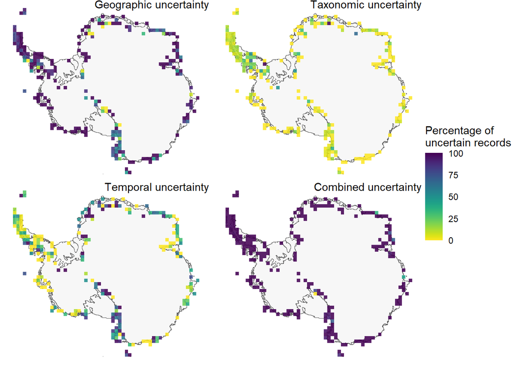

```r
# Plotting  -----------------------------------------------------------

geog_unc_rastdf <- as.data.frame(geog_unc_rast, xy = TRUE)

geog_unc_plot <- ggplot() +
 geom_sf(data = coast, fill = "grey94", alpha = 0.5, size = 0.00001) +
geom_tile(data = geog_unc_rastdf, aes(x, y, fill = Perc_Unc), alpha = 0.87) +
  scale_fill_viridis(direction = -1) +
  labs(x = "Longitude", y = "Latitude", fill = str_wrap("Percentage of uncertain records", 18)) +
  guides(fill = guide_colourbar(ticks = F)) +
  theme_void()

geog_unc_plot <- geog_unc_plot + annotate("text", x = Inf, y = Inf, label = "Geographic uncertainty", vjust = 1, hjust = 1)

taxo_unc_rastdf <- as.data.frame(taxo_unc_rast, xy = TRUE)

taxo_unc_plot <- ggplot() +
  geom_sf(data = coast, fill = "grey94", alpha = 0.5, size = 0.00001) +
  geom_tile(data = taxo_unc_rastdf, aes(x, y, fill = Perc_Unc), alpha = 0.87) +
  scale_fill_viridis(direction = -1) + #invert colour scale
  labs(x = "Longitude", y = "Latitude", fill = str_wrap("Percentage of uncertain records", 16)) +
  guides(fill = guide_colourbar(ticks = F)) +
  theme_void()

taxo_unc_plot <- taxo_unc_plot + annotate("text", x = Inf, y = Inf, label = "Taxonomic uncertainty", vjust = 1, hjust = 1)


temp_unc_rastdf <- as.data.frame(temp_unc_rast, xy = TRUE)

temp_unc_plot <- ggplot() +
  geom_sf(data = coast, fill = "grey94", alpha = 0.5, size = 0.00001) +
  geom_tile(data = temp_unc_rastdf, aes(x, y, fill = Perc_Unc), alpha = 0.87) +
  scale_fill_viridis(direction = -1) + #invert colour scale
  labs(x = "Longitude", y = "Latitude", fill = str_wrap("Percentage of uncertain records", 16)) +
  guides(fill = guide_colourbar(ticks = F)) +
  theme_void()

temp_unc_plot <- temp_unc_plot + annotate("text", x = Inf, y = Inf, label = "Temporal uncertainty", vjust = 1, hjust = 1)


combined_unc_rastdf <- as.data.frame(combined_unc_rast, xy = TRUE)

combined_unc_plot <- ggplot() +
  geom_sf(data = coast, fill = "grey94", alpha = 0.5, size = 0.00001) +
  geom_tile(data = combined_unc_rastdf, aes(x, y, fill = Perc_Unc), alpha = 0.87) +
  scale_fill_viridis(direction = -1) + #invert colour scale
  labs(x = "Longitude", y = "Latitude", fill = str_wrap("Percentage of uncertain records", 16)) +
  guides(fill = guide_colourbar(ticks = F)) +
  theme_void()

combined_unc_plot <- combined_unc_plot + annotate("text", x = Inf, y = Inf, label = "Combined uncertainty", vjust = 1, hjust = 1)

uncertainty_plot <- ggarrange(geog_unc_plot + rremove("ylab") + rremove("xlab"), taxo_unc_plot + rremove("ylab") + rremove("xlab"), temp_unc_plot + rremove("ylab") + rremove("xlab"), combined_unc_plot + rremove("ylab") + rremove("xlab"), nrow = 2, ncol = 2, align = "v", common.legend = TRUE, legend = "right")

print(uncertainty_plot)
```

## Spatial autocorrelation of uncertainty

Using Moran’s I from the package `spdep`, calculate the spatial autocorrelation of the grid cell uncertainty. First we set up the neighbourhood distance to define cells that are considered ‘adjacent’. We chose neighbourhood distances for our 100km resolution to be 150km. Neighbours are therefore adjacent by the Queen’s adjacency rule.

[output not shown]

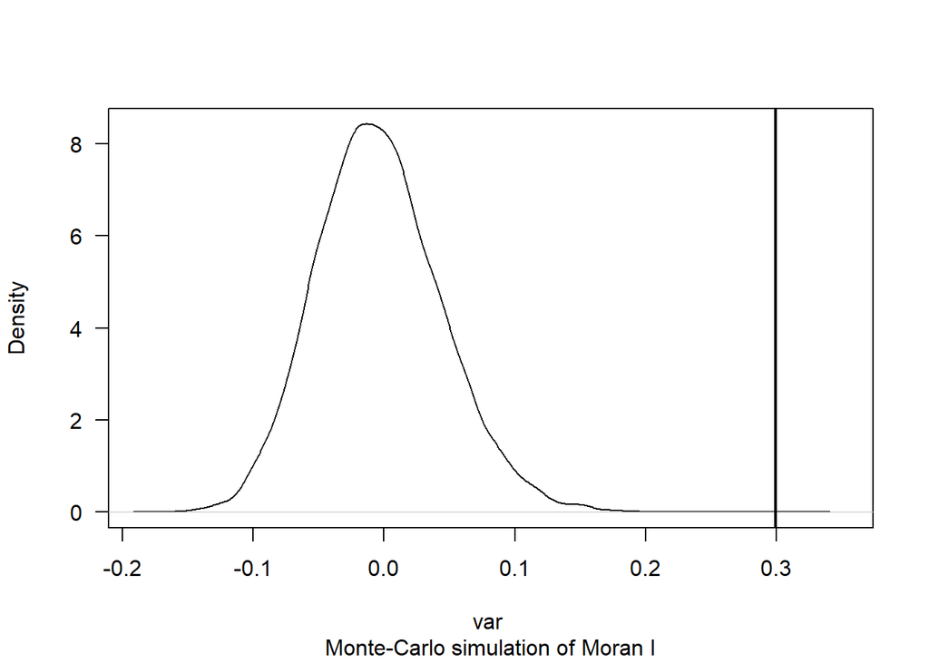

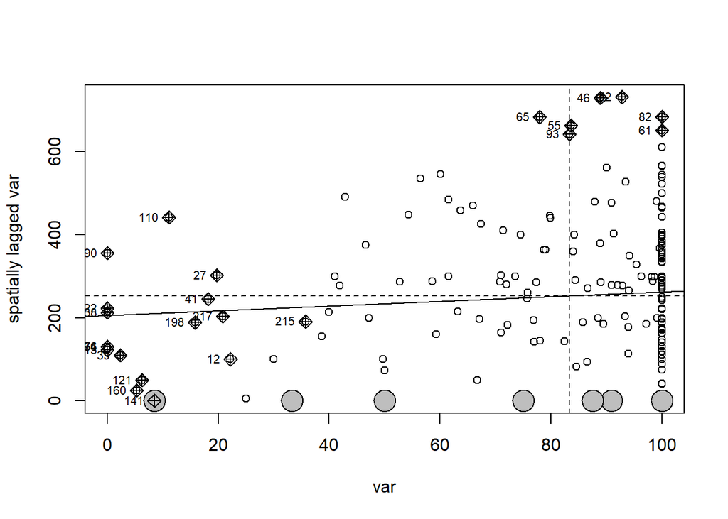

```
## Spatial correlogram for norm_var
## method: Moran's I
##           estimate expectation   variance standard deviate Pr(I) two sided
## 1 (209)  0.3222234  -0.0048077  0.0034012           5.6076       1.847e-07 ***
## 2 (192)  0.1120674  -0.0052356  0.0040178           1.8506           0.578
## 3 (170)  0.0538379  -0.0059172  0.0047901           0.8634           1.000
## 4 (147)  0.0249911  -0.0068493  0.0056419           0.4239           1.000
## 5 (129)  0.0335808  -0.0078125  0.0061401           0.5283           1.000
## 6 (115)  0.0676243  -0.0087719  0.0063985           0.9551           1.000
## 7 (99)   0.0701450  -0.0102041  0.0069049           0.9669           1.000
## 8 (84)   0.0113646  -0.0120482  0.0080145           0.2615           1.000
## 9 (69)   0.0324366  -0.0147059  0.0092964           0.4889           1.000
## ---
## Signif. codes:  0 '***' 0.001 '**' 0.01 '*' 0.05 '.' 0.1 ' ' 1
```

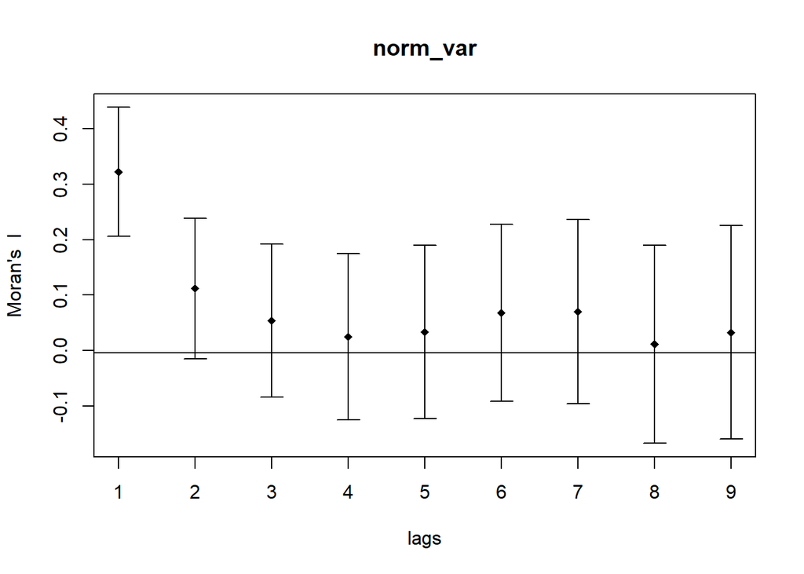

```
## [1] "update_rast_xy created"
## [1] "...Nearest neighbours found..."
## [1] "...Weights calculated..."
## [1] "...Moran's I calculated..."
## [1] "...Bootstrapping finished..."
##
##  Monte-Carlo simulation of Moran I
##
## data:  var
## weights: weights
## number of simulations + 1: 10001
##
## statistic = 0.11803, observed rank = 9869, p-value = 0.0132
## alternative hypothesis: greater
```

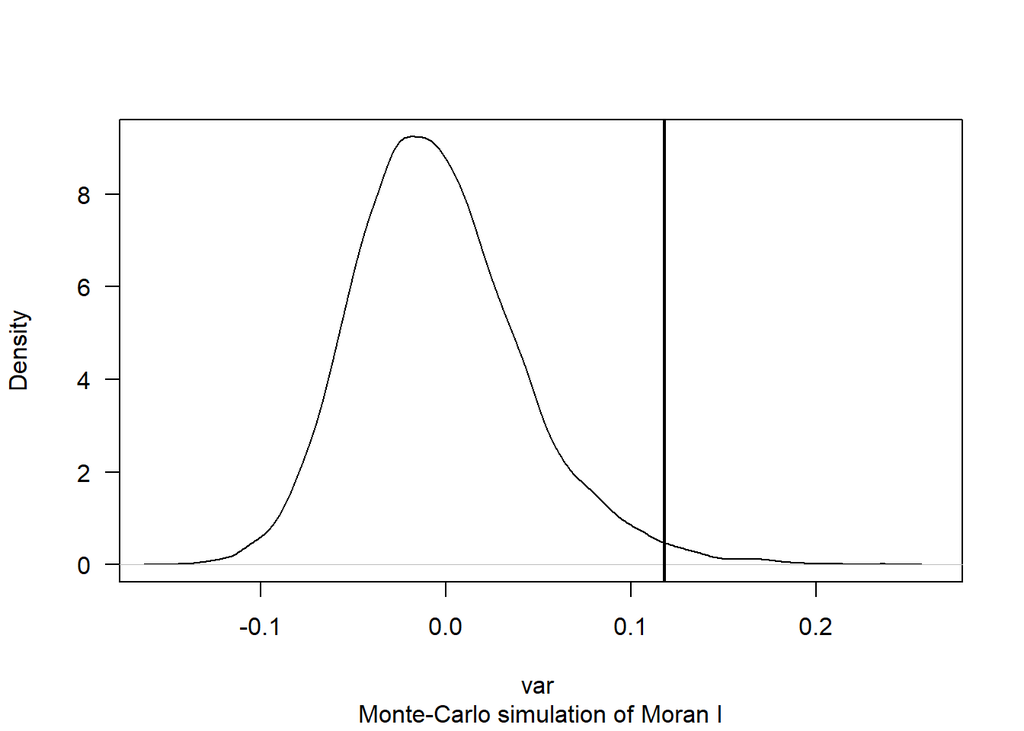

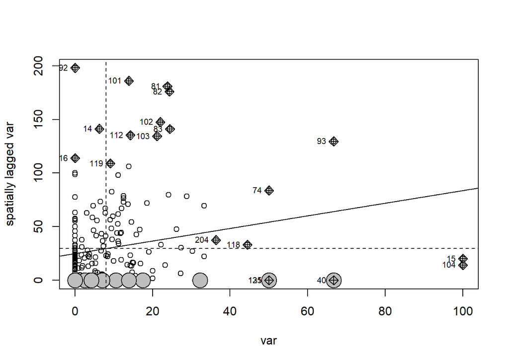

```
## Spatial correlogram for norm_var
## method: Moran's I
##            estimate expectation    variance standard deviate Pr(I) two sided
## 1 (209)  0.06023875 -0.00480769  0.00316695           1.1559          1.0000
## 2 (192)  0.13096791 -0.00523560  0.00371600           2.2343          0.2291
## 3 (170)  0.12415018 -0.00591716  0.00438254           1.9647          0.4450
## 4 (147) -0.00017415 -0.00684932  0.00508321           0.0936          1.0000
## 5 (129)  0.12098055 -0.00781250  0.00544154           1.7459          0.7274
## 6 (115)  0.05515943 -0.00877193  0.00557511           0.8562          1.0000
## 7 (99)   0.08383287 -0.01020408  0.00586364           1.2280          1.0000
## 8 (84)   0.09808302 -0.01204819  0.00657717           1.3580          1.0000
## 9 (69)   0.05754614 -0.01470588  0.00722152           0.8502          1.0000
```

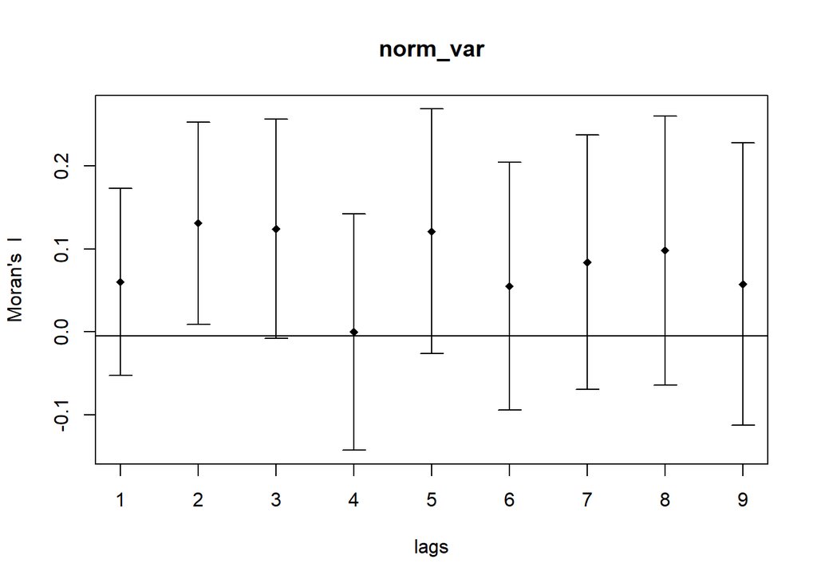

```
## [1] "update_rast_xy created"
## [1] "...Nearest neighbours found..."
## [1] "...Weights calculated..."
## [1] "...Moran's I calculated..."
## [1] "...Bootstrapping finished..."
##
##  Monte-Carlo simulation of Moran I
##
## data:  var
## weights: weights
## number of simulations + 1: 10001
##
## statistic = 0.36916, observed rank = 10001, p-value = 9.999e-05
## alternative hypothesis: greater
```

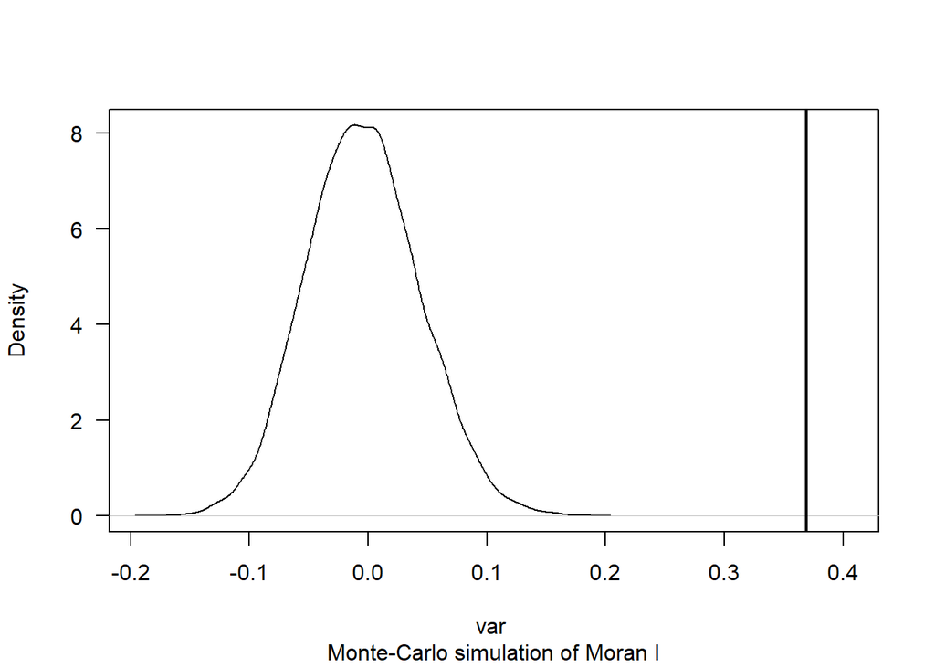

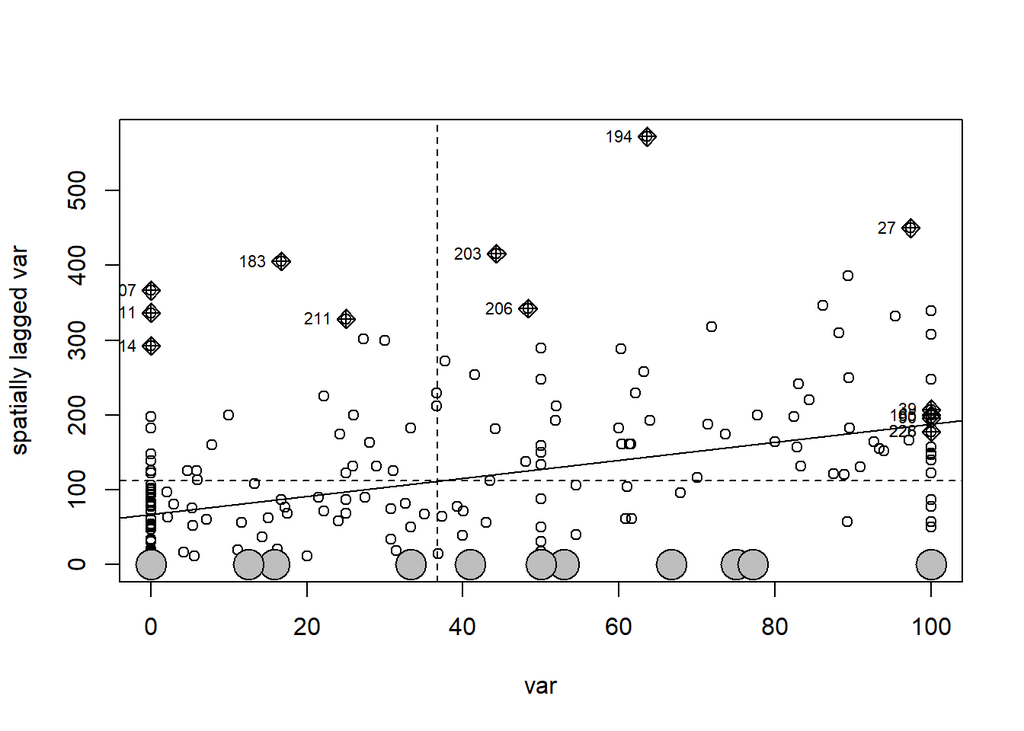

```
## Spatial correlogram for norm_var
## method: Moran's I
##           estimate expectation   variance standard deviate Pr(I) two sided
## 1 (209)  0.3780023  -0.0048077  0.0034579           6.5100       6.765e-10 ***
## 2 (192)  0.2330928  -0.0052356  0.0040908           3.7262        0.001749 **
## 3 (170)  0.2059093  -0.0059172  0.0048888           3.0295        0.022043 *
## 4 (147)  0.1722860  -0.0068493  0.0057772           2.3568        0.165902
## 5 (129)  0.1758115  -0.0078125  0.0063092           2.3118        0.187120
## 6 (115)  0.1131318  -0.0087719  0.0065979           1.5008        1.000000
## 7 (99)   0.1338248  -0.0102041  0.0071571           1.7025        0.797995
## 8 (84)   0.1491199  -0.0120482  0.0083626           1.7624        0.701984
## 9 (69)   0.0575085  -0.0147059  0.0097988           0.7295        1.000000
## ---
## Signif. codes:  0 '***' 0.001 '**' 0.01 '*' 0.05 '.' 0.1 ' ' 1
```

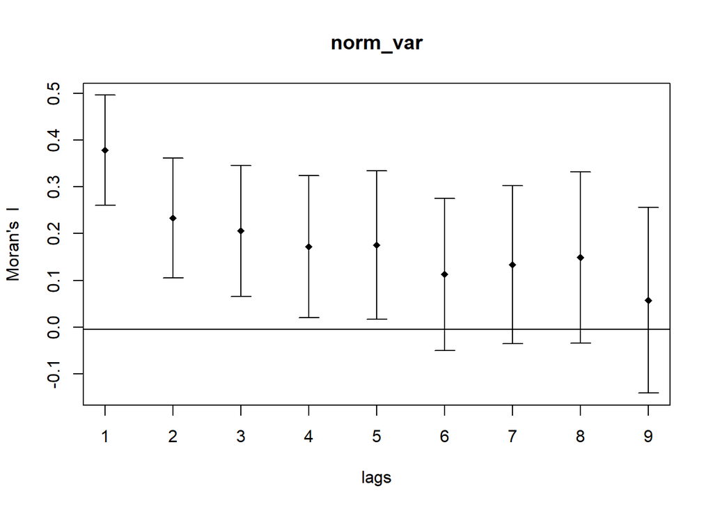

```r
# List the uncertainty rasters
unc_rast_list <- list(geog_unc_rast, taxo_unc_rast, temp_unc_rast)

# Create an index
i <- list(1,2,3)

# Set up the dataframe for saving
MoransI <- data.frame(Uncertainty = numeric(), MoransI = numeric())


MoransI_func <- function(unc, i) {

  # Calculating Moran's I  -------------------------------------------------

  # Calculate the neighbourhood distance as 1.5 x resolution
  neighbour_dist <- 150000

  update_rast_xy <- unc %>%
    as.data.frame(xy=TRUE) %>%
    .[, -3] #remove n

  print("update_rast_xy created")

  # dnearneigh is in metres, finds to index of all values within the specified distance
  nb1 <- dnearneigh(as.matrix(update_rast_xy), 0, neighbour_dist)

  # For viewing which neighbours are selected
  # plot(nb1, coords = as.matrix(update_rast_xy))

  print("...Nearest neighbours found...")

  # Print list of distances
  # dists <- nbdists(nb1, update_rast_xy)

  # Generate a weights object
  weights <- nb2listw(nb1,
                      glist = NULL,
                      style = "B",
                      zero.policy = TRUE)

  print("...Weights calculated...")

  # Then extract just the values per cell
  var <- unc %>%
    as.data.frame() %>%
    .[,1]

  # Normalize the data so it is not affected by high values
  normalize <- function(x, na.rm = TRUE) {
    return((x- min(x)) /(max(x)-min(x)))
  }

  norm_var <- normalize(var)

  # Moran's I value for normalized data
  I <- moran(norm_var,
             weights,
             zero.policy = T,
             length(nb1),
             Szero(weights)) %>%
    .[[1]]

  print("...Moran's I calculated...")

  # Add output to dataframe
  MoransI <<- MoransI %>%
    add_row(Uncertainty = i, MoransI = I)

  # Hypothesis test  ----------------------------------------------------

  # Run a hypothesis test via permutation
  set.seed(1)
  moran_bootstrap <- moran.mc(var,
                              weights,
                              nsim = 10000,
                              zero.policy = TRUE)

  print("...Bootstrapping finished...")

  # Print summary outputs  ----------------------------------------------

  # Print the output of the hypothesis test
  print(moran_bootstrap)

  # Plot the density of expected (under randomisation) vs. observed values of Moran's I
  plot(moran_bootstrap, main="", las=1)

  # Plot the relationship between a cell's value (% records lost from uncertainty) and its nearest neighbour values
  moran.plot(var, weights, zero.policy = T)

  # Calculate the number of bins for a correlogram according to Sturge's rule (refer to Borcard et al. 2018)
  no_recs <- unc %>%
    as.data.frame() %>%
    nrow()

  no_dists <- round(1 + 3.322*log10(no_recs))

  # Generate a correlogram to examine the spatial scale of correlation
  subs.correlog <-
    sp.correlogram(nb1,
                   norm_var,
                   order = no_dists,
                   method = "I",
                   zero.policy = TRUE)

  # Print the results with a "Holm" correction for multiple testing
  print(subs.correlog, p.adj.method = "bonferroni")

  plot(subs.correlog)

}


# Map the correlation function -------------------------------------------------------

map2(unc_rast_list, i, MoransI_func)
```

```r
# Print the dataframe of estimates
print(MoransI)
```

```
##   Uncertainty   MoransI
## 1           1 0.3265437
## 2           2 0.1287546
## 3           3 0.4027191
```

## References

Borcard, D., Gillet, F. and Legendre, P., 2018. Numerical ecology with R (Vol. 2, p. 688). New York: Springer.